# Wstęp do uczenia maszynowego

# Modele

Skonstruujemy teraz kilka modeli predykcyjnych. Jako, że w naszym zbiorze występują kontrowersyjne kolumny `sex` oraz `race`, zbudujemy modele zarówno na danych ze wszystkimi zmiennymi, a także po wykluczeniu tych dwóch konkretnych.

```python
census_dfv2 = census_df.drop('sex', axis = 1)
census_dfv2 = census_dfv2.drop('race', axis = 1)

census_df_testv2 = census_df_test.drop('sex', axis = 1)
census_df_testv2 = census_df_testv2.drop('race', axis = 1)
```

#### Regresja Logistyczna

Na początek wykorzystamy regresję logistyczną. Wykorzystamy już wcześniej zdefiniowany model `lr`.

```python
lr.fit(census_df, y_train)
res = lr.predict(census_df_test)
res
```

```
array([0, 0, 0, ..., 0, 0, 0], dtype=int64)
```

```python
accuracy_score(y_test, res)
```

```
0.7795673240974544
```

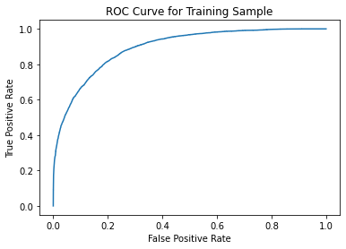

```
gini_test: 0.7899
```

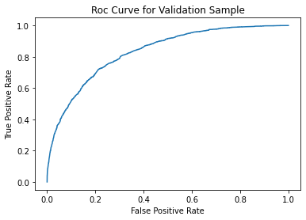

```
gini_val: 0.6629
```

```python
gini_train_val(lr, census_df, y_train, census_df_test, y_test)
```

Zarówno acuracy score jak i wskaźnik gini dla podstawowego zbioru testowego są na wysokim poziomie. Teraz sprawdźmy predykcyjność dla zbioru pozbawionego zmiennych `sex` i `race`

```python
lr.fit(census_dfv2, y_train)
res = lr.predict(census_df_testv2)
res
```

```
array([1, 1, 1, ..., 1, 1, 1], dtype=int64)
```

```python
accuracy_score(y_test, res)
```

```
0.601310311881526
```

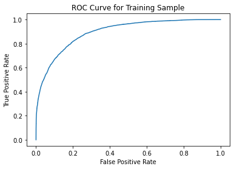

```
gini_test: 0.7895
```

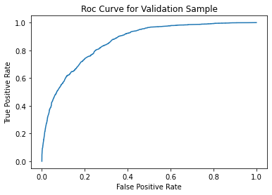

```
gini_val: 0.7248
```

```python
gini_train_val(lr, census_dfv2, y_train, census_df_testv2, y_test)
```

#### Drzewo decyzyjne

```python
from sklearn.tree import DecisionTreeClassifier

Tree = DecisionTreeClassifier()
Tree.fit(census_df, y_train)
res = Tree.predict(census_df_test)
res
```

```
array([0, 0, 0, ..., 1, 1, 0], dtype=int64)
```

```python
accuracy_score(y_test, res)
```

```
0.6473077185559271
```

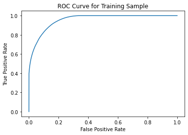

```
gini_test: 0.9124
```

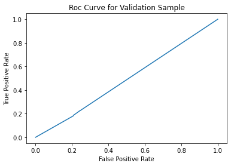

```
gini_val: -0.0211
```

```python
gini_train_val(Tree, census_df, y_train, census_df_test, y_test)
```

```python
Tree.fit(census_dfv2, y_train)
res = Tree.predict(census_df_testv2)
res
```

```
array([1, 1, 1, ..., 1, 1, 1], dtype=int64)
```

```python
accuracy_score(y_test, res)
```

```
0.44107008803657954
```

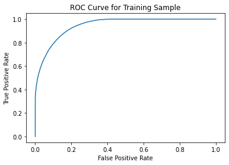

```
gini_test: 0.8910
```

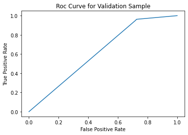

```
gini_val: 0.2346
```

```python
gini_train_val(Tree, census_dfv2, y_train, census_df_testv2, y_test)
```

#### K-najbliższych sąsiadów

```python
from sklearn.neighbors import KNeighborsClassifier

knc = KNeighborsClassifier()
knc.fit(census_df, y_train)
res = knc.predict(census_df_test)
res
```

```
array([0, 0, 0, ..., 0, 0, 0], dtype=int64)
```

```python
accuracy_score(y_test, res)
```

```
0.7936258786596602
```

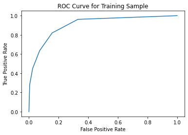

```
gini_test: 0.8133
```

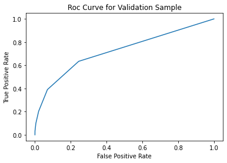

```
gini_val: 0.4481
```

```python
gini_train_val(knc, census_df, y_train, census_df_test, y_test)
```

```python
knc.fit(census_dfv2, y_train)
res = knc.predict(census_df_testv2)
res
```

```
array([1, 1, 1, ..., 1, 1, 1], dtype=int64)
```

```python
accuracy_score(y_test, res)
```

```
0.6281990036170068
```

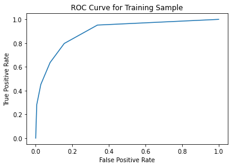

```
gini_test: 0.7948
```

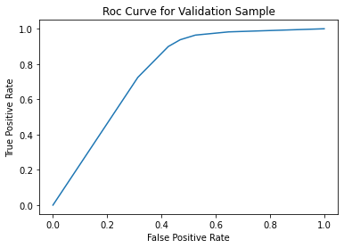

```
gini_val: 0.5331
```

```python
gini_train_val(knc, census_dfv2, y_train, census_df_testv2, y_test)
```

#### Las losowy

```python
from sklearn.ensemble import RandomForestClassifier

rf = RandomForestClassifier()
rf.fit(census_df, y_train)
res = rf.predict(census_df_test)
res
```

```
array([0, 0, 1, ..., 0, 1, 0], dtype=int64)
```

```python
accuracy_score(y_test, res)
```

```
0.7810687231283696
```

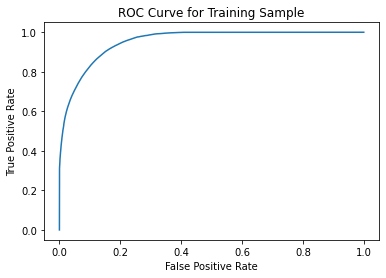

```
gini_test: 0.9074
```

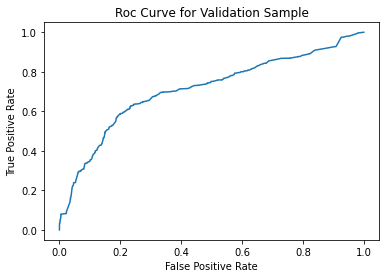

```
gini_val: 0.4191
```

```python
gini_train_val(rf, census_df, y_train, census_df_test, y_test)
```

```python
rf.fit(census_dfv2, y_train)
res = rf.predict(census_df_testv2)
res
```

```
array([1, 1, 1, ..., 1, 1, 1], dtype=int64)
```

```python
accuracy_score(y_test, res)
```

```
0.47137105029686754
```

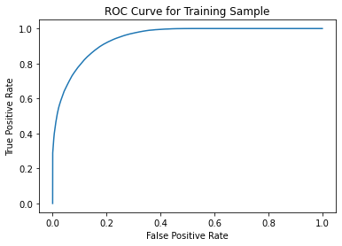

```
gini_test: 0.8870
```

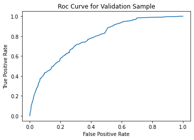

```
gini_val: 0.5605
```

```python
gini_train_val(rf, census_dfv2, y_train, census_df_testv2, y_test)
```

#### AdaBoost

```python
from sklearn.ensemble import AdaBoostClassifier

abc = AdaBoostClassifier()
abc.fit(census_df, y_train)
res = abc.predict(census_df_test)
res
```

```
array([0, 0, 0, ..., 0, 1, 0], dtype=int64)
```

```python
accuracy_score(y_test, res)
```

```
0.8128028390090767
```

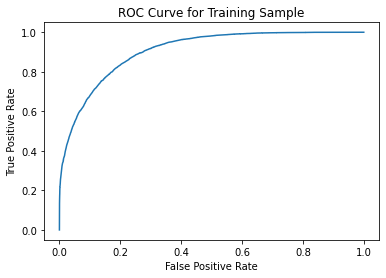

```
gini_test: 0.8118
```

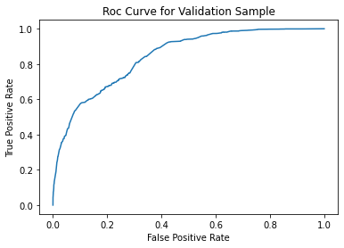

```
gini_val: 0.6887
```

```python
gini_train_val(abc, census_df, y_train, census_df_test, y_test)
```

```python
abc.fit(census_dfv2, y_train)
res = abc.predict(census_df_testv2)
res
```

```
array([1, 1, 1, ..., 1, 1, 1], dtype=int64)
```

```python
accuracy_score(y_test, res)
```

```
0.5263768511567597
```

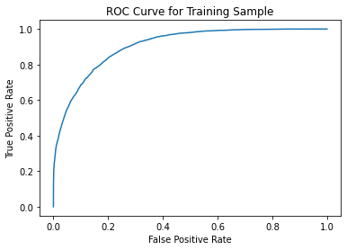

```
gini_test: 0.8120
```

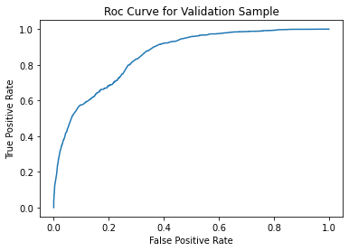

```
gini_val: 0.7103
```

```python
gini_train_val(abc, census_dfv2, y_train, census_df_testv2, y_test)
```

#### Gradient Boosting

```python
from sklearn.ensemble import GradientBoostingClassifier

gb = GradientBoostingClassifier()
gb.fit(census_df, y_train)
res = gb.predict(census_df_test)
res
```

```
array([0, 0, 0, ..., 0, 0, 0], dtype=int64)
```

```python
accuracy_score(y_test, res)
```

```
0.8218112331945676
```

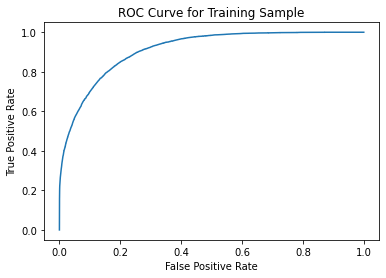

```
gini_test: 0.8243
```

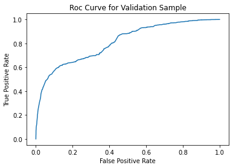

```
gini_val: 0.6208
```

```python
gini_train_val(gb, census_df, y_train, census_df_test, y_test)
```

```python
gb.fit(census_dfv2, y_train)
res = gb.predict(census_df_testv2)
res
```

```
array([1, 1, 1, ..., 1, 1, 1], dtype=int64)
```

```python
accuracy_score(y_test, res)
```

```
0.47669419231556676
```

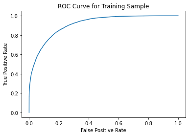

```
gini_test: 0.8225
```

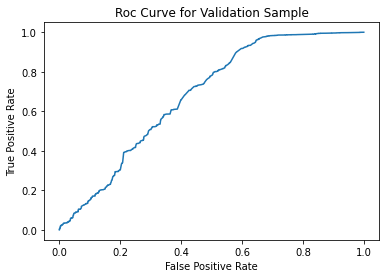

```
gini_val: 0.3614
```

```python
gini_train_val(gb, census_dfv2, y_train, census_df_testv2, y_test)
```